# Ecological Genomics readme file

Antdrew D. Nguyen

2017-01-12

## Welcome to the 2017 Ecological Genomics course!

### Things you’ll need to download:

1. [R](https://www.r-project.org/) and [Rstudio](https://www.rstudio.com/) (be sure to install and load the “knitr”" package)
2. Create a [github](https://github.com/) account and download github [desktop](https://desktop.github.com/)

Access to my whole project can be found on my [github](https://github.com/adnguyen/2017_Ecological_Genomics).

It includes this readme file, which I turned into a website you see here, but it also logs research activities on [my online notebook](https://github.com/adnguyen/2017_Ecological_Genomics/blob/master/Online_notebook.md).

### Common code you’ll need to word process in (R)markdown

1. To embed a link, all you need is the URL, implemented in the following way:

   ```
   [hyperlinked words](URL)
   ```

2. To embed an image, you’ll need a URL of the image, implemented similarly as above:

   ```
   ![](URL)
   ```

   To get a URL in (R)markdown:
   - go to your github repository and click **“Issues”**
   - Click **“New”**
   - Include a title (Pictures); click and drag any image you’d like into the comment section
   - Click **“Submit New Issue”**
   - You will see the image, right click it and copy the URL.
3. To include a table, it is best if you format it first as a csv(comma separated values). (Note, if on a mac, make sure the file type is unicode and unix). With the knitr package, you can generate tables easily from the csv. Here is an example:

Grab a dataset real fast

```r
#packages for reading in data
library(data.table)

#grab dataset online
dat<-fread("https://raw.githubusercontent.com/adnguyen/HelmsCahan_CBP-partA_2016/master/Script_Analyses/Sampling_sites_table.csv")

#making a table
knitr::kable(dat)
```

[output not shown]

```r
str(dat)
```

```
## Classes 'data.table' and 'data.frame':   25 obs. of  7 variables:
##  $ n        : int  1 2 3 4 5 6 7 8 9 10 ...
##  $ Locale   : chr  "Notchview" "Smokey Mountains" "Molly Bog" "Kennebec Highlands" ...
##  $ State    : chr  "MA" "TN" "VT" "ME" ...
##  $ Site ID  : chr  "NO" "GP" "MB" "KH" ...
##  $ Longitude: num  -73 -83.5 -72.6 -69.9 -82 ...
##  $ Latitude : num  42.5 35.6 44.5 44.6 35.9 ...
##  $ Tmax     : num  24.8 25 25.3 25.9 26 26 26 26.4 26.5 26.6 ...
##  - attr(*, ".internal.selfref")=<externalptr>
```

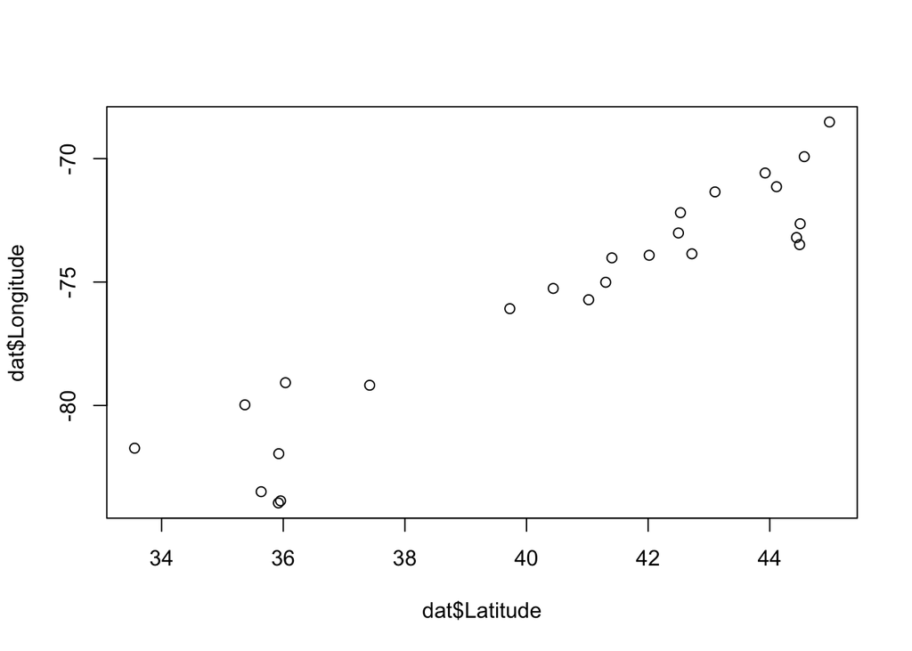

```r
plot(dat$Latitude,dat$Longitude)
```

## Assignments

1st assignment: Creating maps in R

## Final Project

### [good way to annotate your project](http://stackoverflow.com/questions/19699059/representing-directory-file-structure-in-markdown-syntax)